# Tree Based Models

# Part 1: to be completed at home before the lab

In this practical we will cover an introduction to building tree-based models, for the purposes of regression and classification. This will build upon, and review the topics covered in the lecture, in addition to Chapter 8: Tree Based Models in Introduction to Statistical Learning.

Note: the completed homework has to be **handed in** on Black Board and will be **graded** (pass/fail, counting towards your grade for the individual assignment). The deadline is two hours before the start of your lab. Hand-in should be a **PDF** file.

You can download the student zip including all needed files for this practical [here](https://surfdrive.surf.nl/files/index.php/s/OVbWVFnhHVsUaCt). For this practical, you will need the following packages:

```r
# General Packages
library(tidyverse)

# Creating validation and training set
library(caret)

# Decision Trees
library(tree)

# Random Forests & Bagging
library(randomForest)
```

Throughout this practical, we will be using the Red Wine Quality dataset from [Kaggle](https://www.kaggle.com/uciml/red-wine-quality-cortez-et-al-2009).

```r
wine_dat <- read.csv("data/winequality-red.csv")
```

## Decision Trees

When examining classification or regression based problems, it is possible to use decision trees to address them. As a whole, regression and classification trees, follow a similar construction procedure, however their main difference exists in their usage; with regression trees being used for continuous outcome variables, and classification trees being used for categorical outcome variables. The other differences exist at the construction level, with regression trees being based around the average of the numerical target variable, with classification tree being based around the majority vote.

Knowing the difference between when to use a classification or regression tree is important, as it can influence the way you process and produce your decision trees.

1. **Using this knowledge about regression and classification trees, determine whether each of these research questions would be best addressed with a regression or classification tree.**

Hint: Check the data sets in the *Help* panel in the `Rstudio` GUI.

- 1a. Using the `Hitters` data set; You would like to predict the Number of hits in 1986 (`Hits` Variable), based upon the number of number of years in the major leagues (`Years` Variable) and the number of times at bat in 1986 (`AtBat` Variable).
- 1b. Using the `Hitters` data set; You would like to predict the players 1987 annual salary on opening day (`Salary` variable), based upon the number of hits in 1986 (`Hits` variable), the players league (`League` variable) and the number of number of years in the major leagues (`Years` Variable).
- 1c. Using the `Diamonds` data set; You would like to predict the quality of the diamonds cut (`cut` variable) based upon the price in US dollars (`price` variable) and the weight of the diamond (`carat` variable).
- 1d. Using the `Diamonds` data set; You would like to predict the price of the diamond in US dollars (`price` variable), based upon the diamonds colour (`color` variable) and weight (`carat` variable).
- 1e. Using the `Diamonds` data set; You would like to predict how clear a diamond would be (`clarity` variable), based upon its price in US dollars (`price` variable) and cut (`cut` variable).
- 1f. Using the `Titanic` data set; You would like to predict the survival of a specific passenger (`survived` variable), based upon their class (`Class` variable), sex (`Sex` variable) and age (`Age` variable).

```r
# 1a. Regression Tree; The outcome, `Hits` is continuous.
# 1b. Regression Tree; The outcome, `Salary` is continuous.
# 1c. Classification Tree; The outcome, `cut` is discrete/categorical (with less than 7 categories)
# 1d. Regression Tree; The outcome, `price` is continuous.
# 1e. Could be a Regression or Classification tree as the outcome variable is a discrete variable with 7 categories.
# 1f. Classification Tree; The outcome, `survived` is discrete/categorical (with less than 7 categories)
```

## Classification trees

Before we start *growing* our own decision trees, let us first explore the data set we will be using for these exercises. This as previously mentioned is a data set from [Kaggle](https://www.kaggle.com/), looking at the Quality of Red Wine from Portugal. Using the functions `str()` and `summary()`, explore this data set (`wine_dat`).

As you can see this contains over 1500 observations across 12 variables, of which 11 can be considered continuous, and 1 can be considered categorical (`quality`).

Now we have explored the data this practical will be structured around, let us focus on how to *grow* classification trees. The research question we will investigate is whether we can predict wine quality, classified as *Good* (Quality > 5) or *Poor* (Quality <= 5), by the Fixed Acidity (`fixed_acidity`), amount of residual sugars (`residual_sugar`), pH (`pH`) and amount of sulphates (`sulphates`).

Before we *grow* this tree, we must create an additional variable, which indicates whether a wine is of *Good* or *Poor* quality, based upon the quality of the data.

2. **Using the code below, create a new variable `bin_qual` (short for binary quality) as part of the `wine_dat` data set.**

```r
  wine_dat$bin_qual <- ifelse(wine_dat$quality <= "5", "Poor", "Good")
  wine_dat$bin_qual <- as.factor(wine_dat$bin_qual)
```

Next, we will split the data set into a *training* set and a *validation* set (for this practical, we are not using a test set). As previously discussed in other practicals these are incredibly important as these are what we will be using to develop (or train) our model before confirming them. *As a general rule of thumb for machine learning, you should use a 80/20 split, however in reality use a split you are most comfortable with!*

3. **Use the code given below to set a seed of 1003 (for reproducibility) and construct a training and validation set.**

```r
set.seed(1003)
train_index <- createDataPartition(wine_dat$bin_qual, p = .8,
                                  list = FALSE,
                                  times = 1)

wine_train <- wine_dat[train_index,]
wine_valid <- wine_dat[-train_index,]
```

### Building Classification Trees

Now that you have split the quality of the wine into this dichotomous pair and created a training and validation set, you can *grow* a classification tree. In order to build up a classification tree, we will be using the function `tree()` from the [`tree`](https://cran.r-project.org/web/packages/tree/index.html) package, it should be noted although there are multiple different methods of creating decision trees, we will focus on the `tree()` function. As such this requires the following minimum components:

- formula
- data
- subset

When *growing* a tree using this function, it works in a similar way to the `lm()` function, regarding the input of a formula, specific of the data and additionally how the data should be sub-setted.

4. **Using the `tree()` function, grow a tree to investigate whether we can predict wine quality classified as *Good* (Quality > 5) or *Poor* (Quality <= 5), by `fixed_acidity`, `residual_sugar`, `pH` and `sulphates`.**

```r
tree_qual <- tree(formula = bin_qual ~ fixed_acidity + residual_sugar + pH + sulphates,
                     data = wine_train)
```

### Plotting Classification Trees

When plotting decision trees, most commonly this uses the `base` R’s `plot()` function, rather than any `ggplot()` function. As such to plot a regression tree, you simply need to run the function `plot()` including the model as its main argument.

5. **Using the `plot()` function, plot the outcome object of your regression tree.**

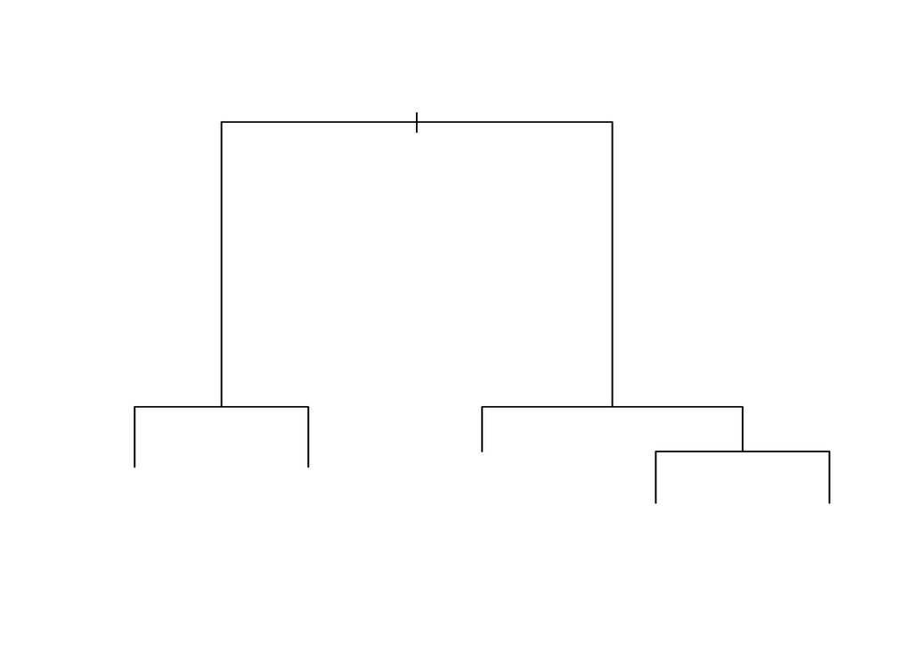

```r
plot(tree_qual)
```

As you can see when you plot this, this only plots the empty decision tree, as such you will need to add a `text()` function separately.

6. **Repeat plotting the outcome object of your regression tree, with in the next line adding the`text()` function, with as input `your_tree_model` and `pretty = 0`.**

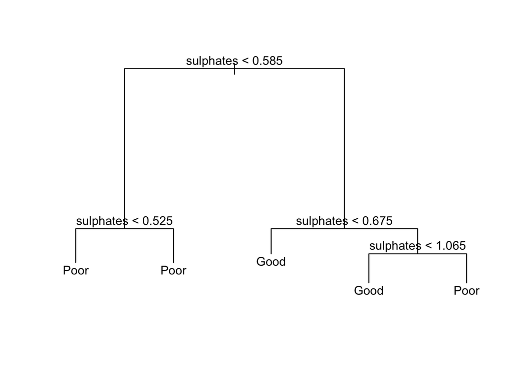

```r
plot(tree_qual)
text(tree_qual, pretty = 0)
```

This now adds the text to the to the decision tree allowing it to be specified visually.

Although plotting the regression tree can be useful for displaying how a topic is split, it only goes some way to answering the research question presented. As such, additional steps are required to ensure that the tree is efficiently fitted.

Firstly, you can explore the layout of the current model using the `summary()` function. This displays the predictors used within the tree; the number of terminal nodes; the residual mean deviance and the distribution of the residuals.

7. **Using the `summary()` function, examine the current decision tree, and report the number of terminal nodes and the residual mean deviance.**

```r
summary(tree_qual)
```

```
##
## Classification tree:
## tree(formula = bin_qual ~ fixed_acidity + residual_sugar + pH +
##     sulphates, data = wine_train)
## Variables actually used in tree construction:
## [1] "sulphates"
## Number of terminal nodes:  5
## Residual mean deviance:  1.235 = 1575 / 1275
## Misclassification error rate: 0.3336 = 427 / 1280
```

# Part 2: to be completed during the lab

## Classification trees continued

### Assessing accuracy and pruning of classification trees

During the homework part, you have fitted a classification tree on the Red Wine Quality dataset. In this first part during the lab, we will continue with your fitted tree, and inspect its overall accuracy and improvement through pruning. To examine the overall accuracy of the model, you should determine the prediction accuracy both for the training and the validation set. Using the predicted and observed outcome values, we can construct a confusion matrix, similar to what we’ve done in week 5 on Classification methods.

So let us build a confusion matrix for the training subset. To begin, once more you need to calculate the predicted value under the model. However, now you need to specify that you want to use `type = "class"`; before forming a table between the predicted values and the actual values. As shown below

```r
# Create the predictions
    yhat_wine_train <- predict(tree_qual, newdata = wine_train, type = "class")

# Obtain the observed outcomes of the training data
    qual_valid <- wine_train[, "bin_qual"]

# Create the cross table:
    tab_wine_train <- table(yhat_wine_train, qual_valid)
    tab_wine_train
```

```
##                qual_valid
## yhat_wine_train Good Poor
##            Good  511  254
##            Poor  173  342
```

The obtained confusion matrix indicates the frequency of a wine predicted as good while it is actually good or poor, and the frequency of wine predicted as poor while actually being good or poor. The frequencies in the confusion matrix are used to determine the accuracy through the formula:

Accuracy = (Total Correct-True Predict [1,1] + Total Correct-False Predictions [2,2]) / total number of items

```r
# Calculate Accuracy accordingly:
  accuracy_wine_train <- (tab_wine_train[1] + tab_wine_train[4]) / 1278

  accuracy_wine_train
```

```
## [1] 0.6674491
```

From this, you can see that this model has an accuracy of around 67% meaning that 67% of the time, it is able to correctly predict from the predictors whether a wine will be of *good* or *poor* quality.

8. **Using this format, create a confusion matrix for the validation subset, and calculate the associated accuracy.**

*Hint*: you can obtain the predicted outcomes for the validation set using `predict(your_tree_model, newdata = wine_valid, type = "class")` and you can extract the observed outcomes of the validation data using `wine_valid[, "bin_qual"]`.

```r
# Create the predictions
    yhat_qual_valid <- predict(tree_qual, newdata = wine_valid, type = "class")

# Obtain the observed outcomes of the validation data
    qual_valid <- wine_valid[, "bin_qual"]

# Create the cross table:
    tab_qual_valid <- table(yhat_qual_valid, qual_valid)
    tab_qual_valid
```

```
##                qual_valid
## yhat_qual_valid Good Poor
##            Good  126   62
##            Poor   45   86
```

```r
# Calculate Accuracy accordingly:
  accuracy_qual_valid <- (tab_qual_valid[1] + tab_qual_valid[4]) / 321

  accuracy_qual_valid
```

```
## [1] 0.6604361
```

Now, let’s evaluate whether pruning this tree may lead to an improved tree. For this, you use the function `cv.tree()`. This runs the tree repeatedly, at each step reducing the number of terminal nodes to determine how this impacts the deviation of the data. You will need to use the argument `FUN = prune.misclass` to indicate we are looking at a classification tree.

9. **Run the model through the `cv.tree()` function and examine the outcome using the `plot()` function using the code below.**

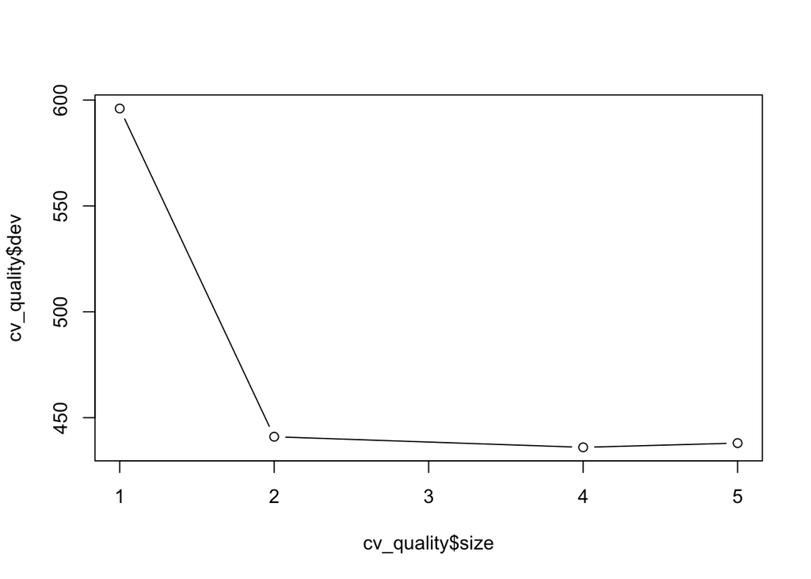

```r
# Determine the cv.tree
  cv_quality <- cv.tree(your_tree_model, FUN=prune.misclass)

# Plot the size vs dev
  plot(cv_quality$size, cv_quality$dev, type = 'b')
```

When you have run this code, you should observe a graph, which plots the `size` (the amount of nodes) against the `dev` (cross-validation error rate). This indicates how this error rate changes depending on how many nodes are used. In this case you should be able to observe a steep drop in `dev` between 1 and 2, before it slowing down from 2 to 5 (the maximum number of nodes used). If you would further like to inspect this, you could compare the accuracy (obtained from the confusion matrices) between these different models, to see which is best fitting. In order to prune the decision tree, you simply use the function `prune.misclass()`, providing both the model and `best = number of nodes` as your arguments.

Note that in the same way as growing classification trees, you can use the function `tree()` to grow regression trees. Regarding the input of the function `tree()` nothing has to be changed: the function detects whether the outcome variable is categorical as seen in the above example, applying classification trees, or continuous, applying regression trees. Differences arise at evaluating the decision tree (inspecting the confusion matrix and accuracy for classification trees or inspecting the MSE for regression trees) and at pruning. To prune a classification tree, you use the function `prune.mislcass()`, while for regression trees the function `prune.tree()` is used.